# An R interface for scLVM

Florian Buettner, F. Paolo Casale and Oliver Stegle

## 1 Data preparation and pre-processing

In order to run scLVM in python as outlined in the demo notebook, it is necessary to pre-process the data. In the following exmaple script we illustrate how this pre-processing was performed for the T-cell data. First, we need to load some required packages.

```r
library(genefilter)
library(DESeq2)
library(statmod)
library(rPython)
library(ggplot2)
library(gplots)
#load the wrapper functions
source('./R2py.R')
source('./scLVM.R')
source('./util.R')
#initialize python
python.load('init_data.py') #please adapt the base path of limix and sclvm here
```

Now, we load two data frames containing, one containing a list of cell cycle genes annotated in Cyclebase, the other one containing mapped read counts for the 81 T-cells described in the paper.

```r
load('data_Tcells.Rdata')
```

Next, we look for the spike-ins which we then use to normalise the data. We omitted the normalization for cell size as proposed in Brennecke et al. 2013, because the computational correction by scLVM yielded much better results . This is likely explained by noting that cell size and cell cycle are correlated, thus the normalization proposed by Brennecke et al. reduces the amount of information available for inferring cell-cell correlations due to cell cycle.

```r
dataMouse[ 1:5, 1:4 ]
```

```
##                    X9108_01.txt X9108_02.txt X9108_03.txt X9108_04.txt
## ENSMUSG00000000001         1678           21          409         1780
## ENSMUSG00000000003            0            0            0            0
## ENSMUSG00000000028         1556            1         3192            2
## ENSMUSG00000000031            0            0            0            0
## ENSMUSG00000000037            0            0            2            0
```

```r
geneTypes <- factor( c( ENSM="ENSM", ERCC="ERCC" )[
  substr( rownames(dataMouse), 1, 4 ) ] )

#2. calculate normalisation for counts
countsMmus <- dataMouse[ which( geneTypes=="ENSM" ), ]
countsERCC <- dataMouse[ which( geneTypes=="ERCC" ), ]
lengthsMmus <- dataMouse[ which( geneTypes=="ENSM" ), 1 ]
lengthsERCC <- dataMouse[ which( geneTypes=="ERCC" ), 1 ]


sfERCC <- estimateSizeFactorsForMatrix( countsERCC )
sfMmus <- sfERCC #also use ERCC size factor for endogenous genes


#normalise read counts
nCountsERCC <- t( t(countsERCC) / sfERCC )
nCountsMmus <- t( t(countsMmus) / sfERCC )
```

Using the normalised read counts and the ERCC spike-ins, we can estimate the technical noise by fitting the relationship between mean and squared coefficient of variation (CV2) following Brennecke et al.

```r
#get technical noise
techNoise = fitTechnicalNoise(nCountsMmus,nCountsERCC=nCountsERCC, fit_type = 'counts')
```

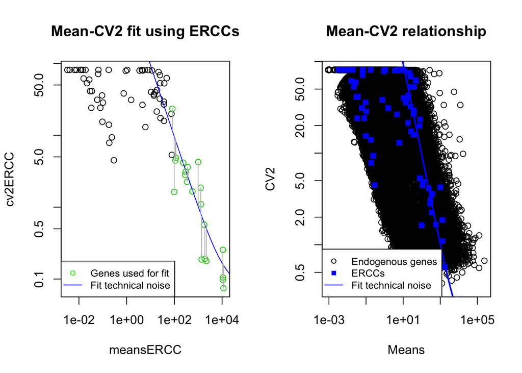

If no spike-ins are available, we can also use the endogenous read counts for fitting the mean-CV2 relation using a log-linear fit in the log-space. Alternatively, we can fit the mean-variance relationship in the log-space using local 2nd order polynomial regression (loess).

```r
techNoiseLogVarFit = fitTechnicalNoise(nCountsMmus, fit_type = 'logvar', use_ERCC = FALSE)
```

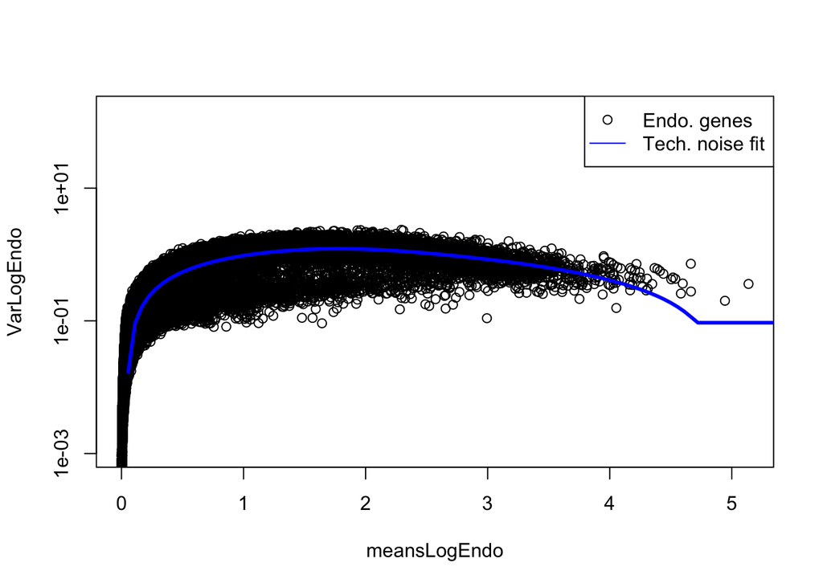

```r
techNoiseLogFit = fitTechnicalNoise(nCountsMmus, fit_type = 'log', use_ERCC = FALSE)
```

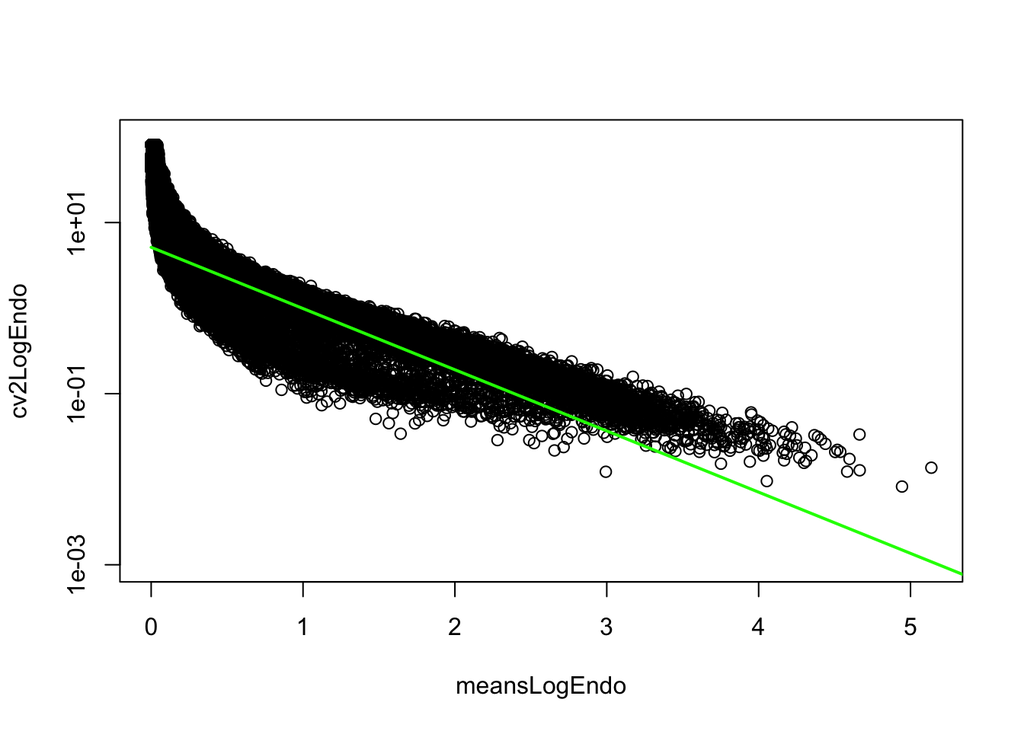

Once we have completed the fitting process, we can call variable genes.

```r
#call variable genes
is_het = getVariableGenes(nCountsMmus, techNoise$fit, method = "fdr",
                          threshold = 0.1, fit_type="counts",sfEndo=sfMmus, sfERCC=sfERCC)
```

[output not shown]

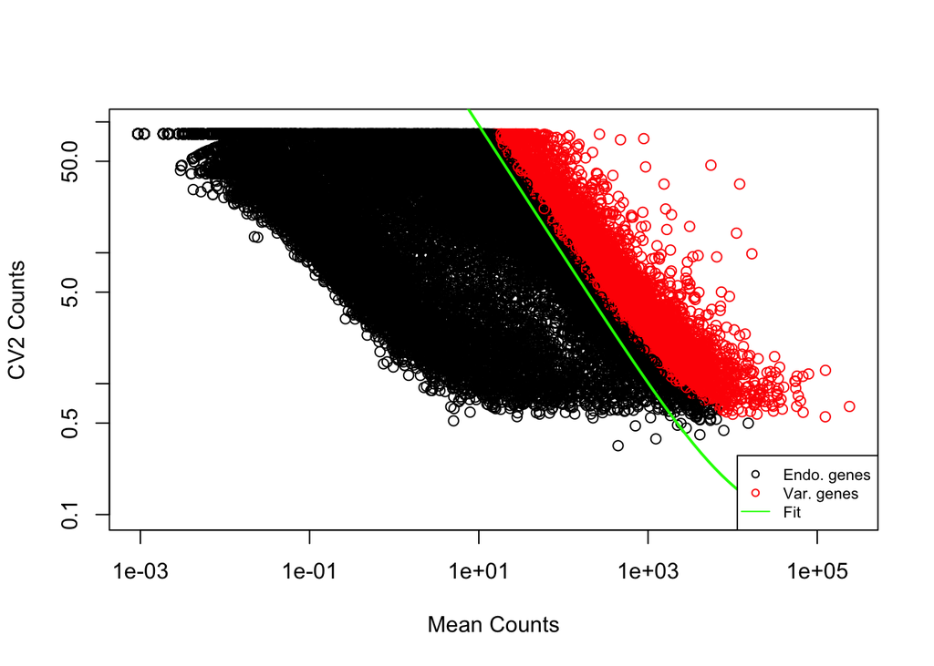

```r
table(is_het)
```

```
## is_het
## FALSE  TRUE
## 31220  7073
```

```r
#we an also do this for the other fits

is_hetLog = getVariableGenes(nCountsMmus, techNoiseLogFit$fit)
```

```
## [1] "No 'fit_type' specified. Trying to guess its from parameter names"
## [1] "Assuming 'fit_type' is 'log'"
```

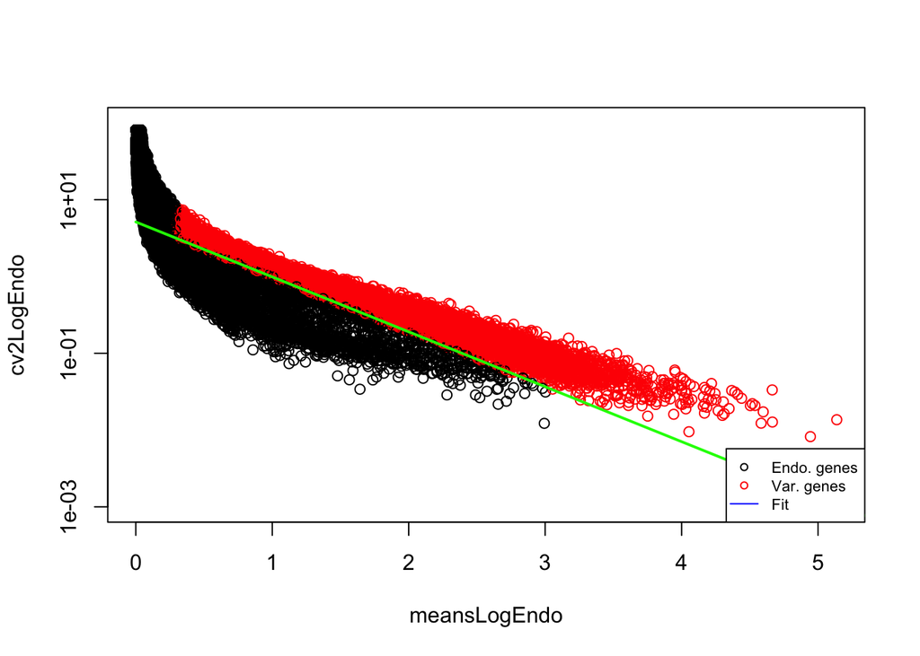

```r
table(is_hetLog)
```

```
## is_hetLog
## FALSE  TRUE
## 29111  9182
```

```r
is_hetLogVar = getVariableGenes(nCountsMmus, techNoiseLogVarFit$fit)
```

```
## [1] "No 'fit_type' specified. Trying to guess its from parameter names"
## [1] "Assuming 'fit_type' is 'logvar'"
## [1] 7099
```

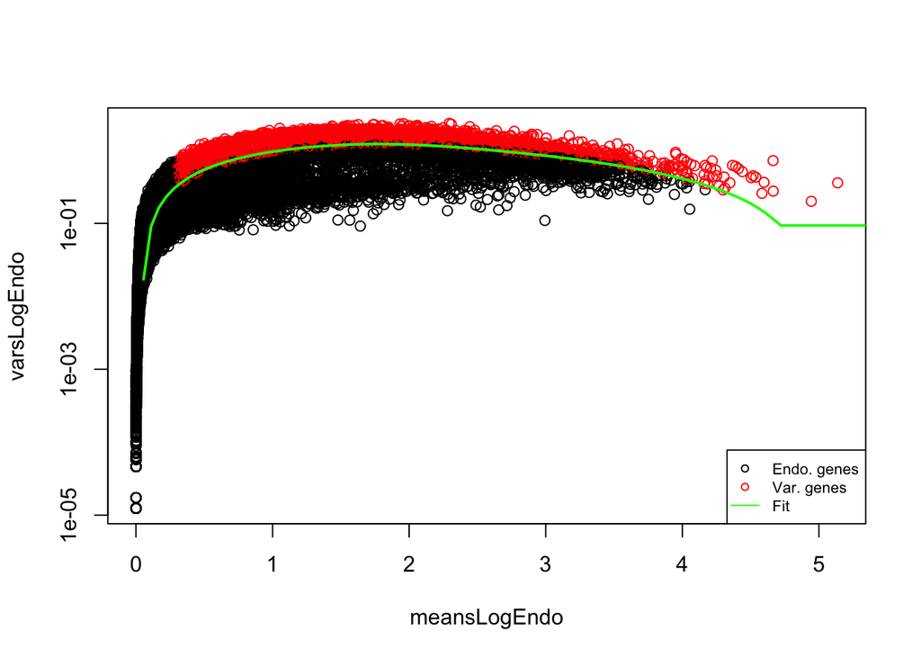

```r
table(is_hetLogVar)
```

```
## is_hetLogVar
## FALSE  TRUE
## 31194  7099
```

In order to fit the latent cell cycle factor we need to retrieve cell cycle genes. For illustration purposes, here we only use genes annotated in GO (term GO:0007049).

```r
#get cell cycle genes from GO
ens_ids_cc <- getEnsemble('GO:0007049')
idx_cellcyclegenes <- na.omit(match(ens_ids_cc, rownames(dataMouse)))
```

Now, we have preprocessed the data and can run scLVM.

```r
#rename a few variables
Y = t(log10(nCountsMmus+1)) #normalised read counts
genes_het_bool = as.vector(is_het) #variable genes
geneID = rownames(nCountsMmus) #gene IDs
tech_noise = as.vector(techNoise$techNoiseLog) #technical noise

#construct scLVM object
sclvm = scLVM(Y=Y)
```

Next, we fit the latent factor. Here, we fit the cell cycle factor. We first use an ARD prior and fit a large number in order to assess how many factors we need in order to capture cell cycle. Note that in this example we expected cell cycle to be the major driver of cell-cell variability

```r
#cell cycle genes
idx_cell_cycle_noise_filtered = intersect(which(colMeans(Y)>0),idx_cellcyclegenes)

#Fit cell cycle factor
k = 20                    # number of latent factors
out_dir = './cache'       # folder where results are cached
file_name = 'Kcc.hdf5'    # name of the cache file
recalc = TRUE             # recalculate X and Kconf
use_ard = TRUE            # use automatic relevance detection


gplvm_ard = fitGPLVM(sclvm,idx=idx_cell_cycle_noise_filtered,k=k,out_dir=out_dir,file_name=file_name,recalc=recalc, use_ard=use_ard)
```

In order to establish the number of latent factors used to model the cell-cell covariance we plot the variance contributions of the individual latent factors.

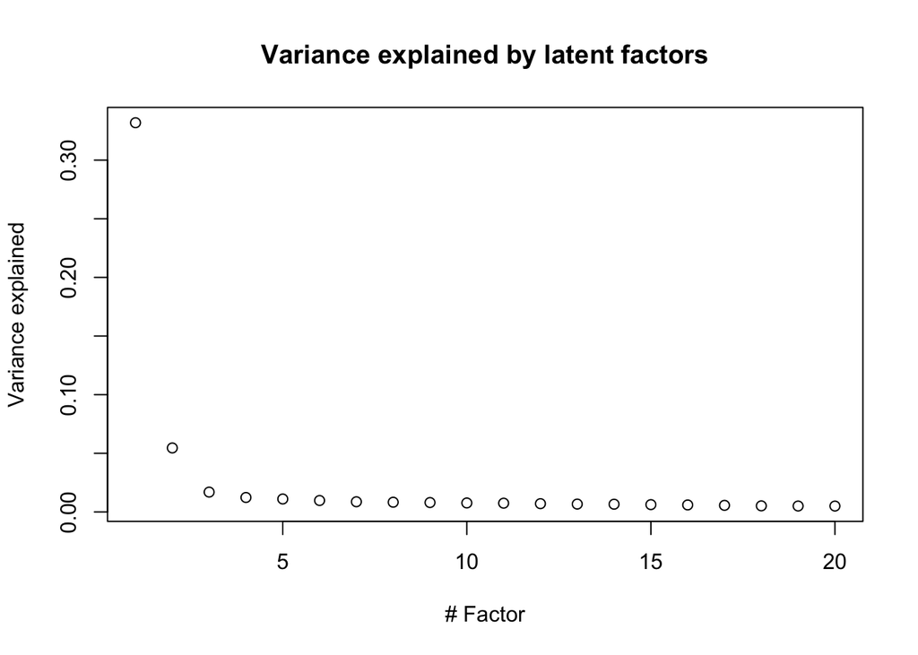

```r
plot(seq(1, length(gplvm_ard$X_ard)), gplvm_ard$X_ard, xlab = '# Factor', ylab = 'Variance explained')
title('Variance explained by latent factors')
```

In this example (and generally when considering cell cycle as the confounding factor), there is a large gap in the proportion of explained variance between the first and the second factor. This suggests, that a single latent factor underlies the variation captured by the cellcycle genes. Consequently, we choose to re-fit the scLVM mdoel with one latent factor only.

```r
gplvm = fitGPLVM(sclvm,idx=idx_cell_cycle_noise_filtered,k=1,out_dir=out_dir,file_name=file_name,recalc=TRUE, use_ard=FALSE)
```

Next, we plot the inferred cell-cell covarince matirx.

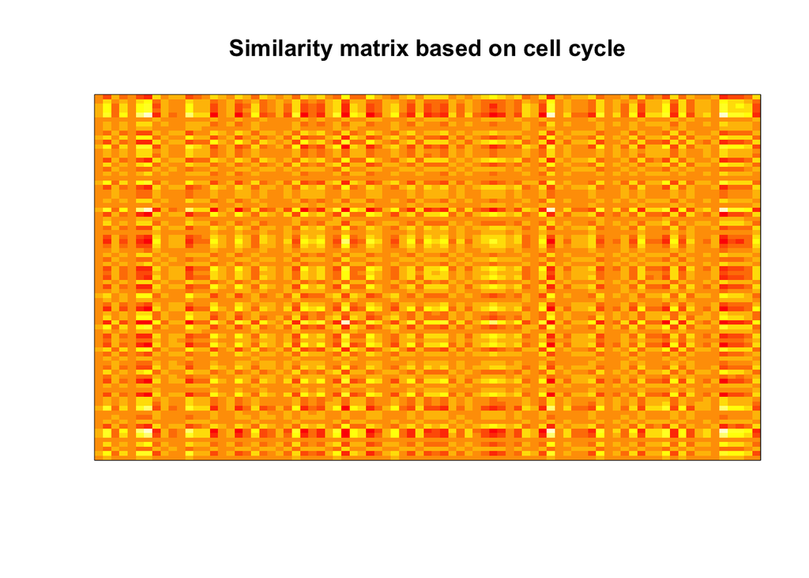

```r
#Plot inferred similarity matrix
Kcc = gplvm$Kcc
image(Kcc,xaxt = "n", yaxt = "n", col = )
title('Similarity matrix based on cell cycle')
```

We first perfrom a variance decomposition on the variable genes.

```r
# considers only heterogeneous genes
Ihet = which(genes_het_bool==1)
Y    = Y[,Ihet]
tech_noise = tech_noise[Ihet]
geneID = geneID[Ihet]

#new instance of sclvm with heterogeneous genes only
sclvm = scLVM(Y=Y,geneID=geneID,tech_noise=tech_noise)
```

```r
i0 = 1    # gene from which the analysis starts
i1 = dim(Y)[2]   # gene at which the analysis ends



# fit the model from i0 to i1
sclvm = varianceDecomposition(sclvm,K=Kcc,i0=i0,i1=i1)
```

Once the contribution of cell cycle to the observed variance is estimated, cell-cycled corrected gene expression levels can be obtained. Variance components are normalised such that they sum uo to 1 and genes for which the variance decompostion has not convered are filtered out.

```r
# get variance components
results_var = getVarianceComponents(sclvm)
var_filtered = results_var$var[results_var$conv,] # filter out genes for which vd has not converged
head(var_filtered)
```

```
##                        hidden_0   biol_noise tech_noise
## ENSMUSG00000000001 4.803430e-01 4.420876e-01 0.07756936
## ENSMUSG00000000028 4.147890e-01 4.160260e-01 0.16918509
## ENSMUSG00000000056 1.406923e-01 3.643481e-01 0.49495956
## ENSMUSG00000000078 5.188897e-01 3.849084e-01 0.09620190
## ENSMUSG00000000085 8.248095e-02 2.685328e-21 0.91751905
## ENSMUSG00000000125 3.802598e-22 1.471125e-21 1.00000000
```

```r
# get corrected expression levels
Ycorr = getCorrectedExpression(sclvm)
dim(Ycorr)
```

```
## [1]   81 7073
```

After having perfromed the variance decompostion we can illustrate the contributions of the indiviudal components.

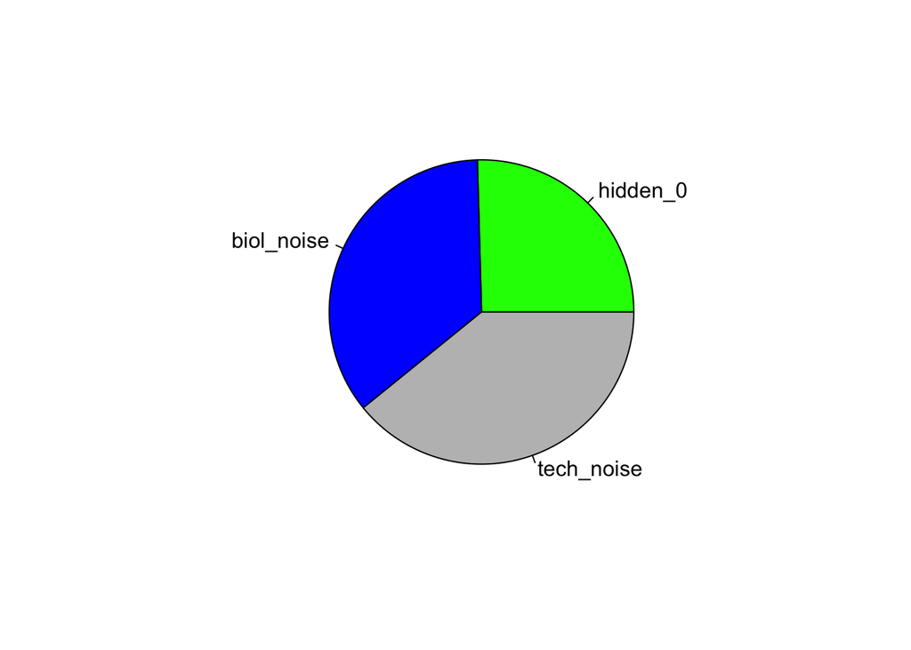

```r
var_mean = apply(var_filtered,2,mean)
colors = c('Green','Blue','Gray')
pie(var_mean, , col = colors)
```

In order to estimate pairwise correlation coefficients whilst controlling for hidden factors such as the cell cycle, we fit a linear mixed model with a fixed effect representing the contribution of another gene j and random effects representing the contribution of the cell cycle and biological variation. Again, as computaion times can be very long we allow the computations to be split up over several calculations for subsets of genes.

```r
i0 = 1     # gene from which the analysis starts
i1 = 5    # gene at which the analysis ends

# fit lmm without correction
res_nocorr = fitLMM(sclvm, K=NULL,i0=i0,i1=i1,verbose=TRUE, geneID = geneID)

# fit lmm with correction
res_corr = fitLMM(sclvm, K=Kcc,i0=i0,i1=i1,verbose=TRUE, geneID = geneID)
```

Finally we can have a quick look at the difference between corrected and uncorrected correlations.

[figure not shown]

```r
heatmap.2(res_nocorr$beta[,i0:i1], Rowv = NULL, Colv = NULL, dendrogram = "none",
          labCol = as.character(seq(i0:i1)), labRow = as.character(seq(i0:i1)),srtCol = 0, key=T,density.info = "none",
          trace="none", breaks=seq.int(from = -0.6, to = 1.0, length.out = 13), main = 'Without Correction')
```

[figure not shown]

```r
heatmap.2(res_corr$beta[,i0:i1], Rowv = NULL, Colv = NULL, dendrogram = "none",
          labCol = as.character(seq(i0:i1)), labRow = as.character(seq(i0:i1)),srtCol = 0, key=T,density.info = "none",
          trace="none", breaks=seq.int(from = -0.6, to = 1.0, length.out = 13), main = 'With Correction')
```

Finally, let’s make a standard PCA on the corrected and uncorrected data. If you would like to use non-linear PCA as in our paper, we suggest you use the python implementation as illustrated in our ipython notebook.

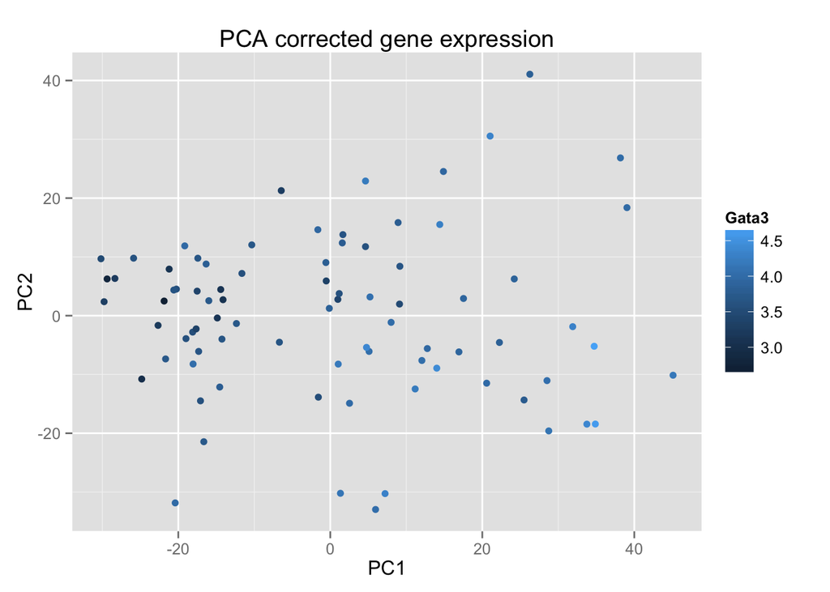

```r
idx_Gata3 = which(geneID=='ENSMUSG00000015619')

#PCA on cell cycle corrected gene expression data
pcaCorr = prcomp(Ycorr,2)
d <- qplot(pcaCorr$x[,1], pcaCorr$x[,2],colour=Ycorr[,idx_Gata3], xlab = 'PC1', ylab = 'PC2')
d + ggtitle('PCA corrected gene expression') + scale_color_continuous(name ="Gata3")
```

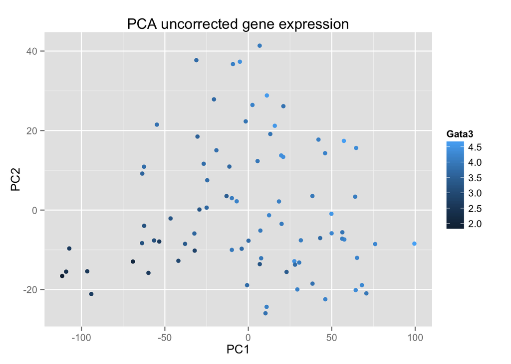

```r
#PCA on uncorrected data
pca = prcomp(Y,2)
d <- qplot(pca$x[,1], pca$x[,2],colour=Y[,idx_Gata3], xlab = 'PC1', ylab = 'PC2')
d + ggtitle('PCA uncorrected gene expression') + scale_color_continuous(name ="Gata3")
```